# assignment

Ieva Gudelytė

2026-04-30

```r
suppressPackageStartupMessages({
  library(epiwraps)
  library(ggplot2)
  library(AnnotationHub)
  library(ensembldb)
  library(edgeR)
  library(rtracklayer)
  library(BiocParallel)
  library(GenomicRanges)
  library(bsseq)   # Class and tools to analyze bisulfite sequencing data at CpG-level
  library(DMRcate) # Identification of differentially-methylated regions
})
ah <- AnnotationHub()
```

# Downloading the data

```r
options(timeout = 6000)
download.file("https://ethz-ins.org/content/w11_practical.zip", "w11_practical.zip")
unzip("w11_practical.zip")
```

```r
# differential accessibility results for the 2nd part of the task:
options(timeout = 6000)
download.file("https://www.ethz-ins.org/content/ATAC_AstroVsESC_subset.rds", "diff_accessibility.rds")
```

# Differential Methylation Testing

## Bsseq object

We will use a BSseq object that contains data from embryonic stem cells (ESC) and astrocytes.

```r
bs <- readRDS("ESC_astrocytes_BSseq.rds")
bs
```

```
## An object of type 'BSseq' with
##   748671 methylation loci
##   4 samples
## has not been smoothed
## All assays are in-memory
```

```r
# remove CpGs that have 0 coverage in some samples:
bs <- bs[rowSums(assay(bs,"Cov")>0)==ncol(bs),]

design <- model.matrix(~celltype, data=pData(bs))
design
```

```
##                        (Intercept) celltypeastrocytes
## astrocytes_ENCFF001TPN           1                  1
## astrocytes_ENCFF001TPP           1                  1
## ESC_ENCFF001TMC                  1                  0
## ESC_ENCFF001TMD                  1                  0
## attr(,"assign")
## [1] 0 1
## attr(,"contrasts")
## attr(,"contrasts")$celltype
## [1] "contr.treatment"
```

```r
# adapt the design for methylation data:
methdesign <- modelMatrixMeth(design)

bs <- BSmooth(bs, BPPARAM=MulticoreParam(4, progress=TRUE))
```

[output not shown]

[output not shown]

[output not shown]

[output not shown]

[output not shown]

[output not shown]

[output not shown]

[output not shown]

[output not shown]

[output not shown]

[output not shown]

[output not shown]

[output not shown]

[output not shown]

[output not shown]

[output not shown]

[output not shown]

[output not shown]

[output not shown]

[output not shown]

[output not shown]

[output not shown]

[output not shown]

[output not shown]

[output not shown]

[output not shown]

[output not shown]

[output not shown]

[output not shown]

[output not shown]

[output not shown]

[output not shown]

[output not shown]

[output not shown]

[output not shown]

[output not shown]

[output not shown]

[output not shown]

[output not shown]

[output not shown]

[output not shown]

[output not shown]

[output not shown]

[output not shown]

[output not shown]

[output not shown]

[output not shown]

[output not shown]

[output not shown]

[output not shown]

[output not shown]

[output not shown]

[output not shown]

[output not shown]

[output not shown]

[output not shown]

[output not shown]

[output not shown]

[output not shown]

[output not shown]

[output not shown]

[output not shown]

[output not shown]

[output not shown]

[output not shown]

[output not shown]

[output not shown]

[output not shown]

[output not shown]

[output not shown]

[output not shown]

[output not shown]

[output not shown]

[output not shown]

[output not shown]

[output not shown]

[output not shown]

[output not shown]

[output not shown]

[output not shown]

[output not shown]

[output not shown]

[output not shown]

[output not shown]

[output not shown]

[output not shown]

[output not shown]

[output not shown]

[output not shown]

[output not shown]

[output not shown]

[output not shown]

[output not shown]

## Testing each CpG individually

```r
# CpG-level tests:
seqAnnot <- sequencing.annotate(bs, methdesign, all.cov=TRUE, coef="celltypeastrocytes")
```

```
## Filtering out all CpGs where at least one sample has zero coverage...
```

```
## Processing BSseq object...
```

```
## Transforming counts...
```

```
## Fitting model...
```

```
## Your contrast returned 45364 individually significant CpGs. We recommend the default setting of pcutoff in dmrcate().
```

```r
# look at the top most significant CpGs:
res <- seqAnnot@ranges
res <- res[order(res$ind.fdr),]
head(res)
```

```
## GRanges object with 6 ranges and 5 metadata columns:
##                   seqnames    ranges strand |      stat     rawpval      diff
##                      <Rle> <IRanges>  <Rle> | <numeric>   <numeric> <numeric>
##   chr10:134587260    chr10 134587260      * |   11.8463 3.09080e-18   13.1913
##    chr10:97850004    chr10  97850004      * |  -10.9676 1.00340e-16  -12.1561
##    chr10:97850011    chr10  97850011      * |  -10.9676 1.00340e-16  -12.1561
##    chr10:97850021    chr10  97850021      * |  -10.9676 1.00340e-16  -12.1561
##   chr14:105011933    chr14 105011933      * |  -11.0440 7.38740e-17  -12.1473
##    chr17:78286176    chr17  78286176      * |   11.1146 5.57213e-17   12.2072
##                       ind.fdr    is.sig
##                     <numeric> <logical>
##   chr10:134587260 2.26339e-12      TRUE
##    chr10:97850004 7.34794e-12      TRUE
##    chr10:97850011 7.34794e-12      TRUE
##    chr10:97850021 7.34794e-12      TRUE
##   chr14:105011933 7.34794e-12      TRUE
##    chr17:78286176 7.34794e-12      TRUE
##   -------
##   seqinfo: 25 sequences from an unspecified genome; no seqlengths
```

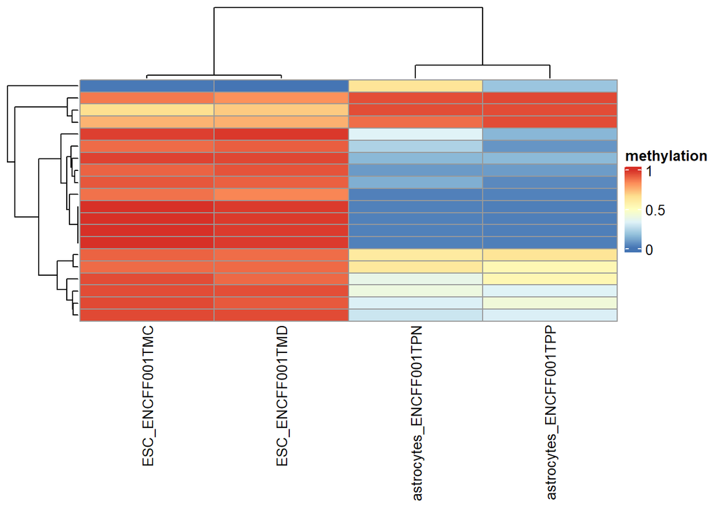

```r
# visualize them across samples:
metCpGs <- bsseq::getMeth(bs, regions=head(res,20), what="perRegion")
colnames(metCpGs) <- colnames(bs)
pheatmap(metCpGs, name="methylation")
```

## Differentially-methylated regions (DMRs)

Identifying broader regions of coherent changes:

```r
dmrcateRes <- dmrcate(seqAnnot, C=2, min.cpgs=5)
```

```
## Fitting chr1...
```

```
## Fitting chr10...
```

```
## Fitting chr11...
```

```
## Fitting chr12...
```

```
## Fitting chr13...
```

```
## Fitting chr14...
```

```
## Fitting chr15...
```

```
## Fitting chr16...
```

```
## Fitting chr17...
```

```
## Fitting chr18...
```

```
## Fitting chr19...
```

```
## Fitting chr2...
```

```
## Fitting chr20...
```

```
## Fitting chr21...
```

```
## Fitting chr22...
```

```
## Fitting chr3...
```

```
## Fitting chr4...
```

```
## Fitting chr5...
```

```
## Fitting chr6...
```

```
## Fitting chr7...
```

```
## Fitting chr8...
```

```
## Fitting chr9...
```

```
## Fitting chrM...
```

```
## Fitting chrX...
```

```
## Fitting chrY...
```

```
## Demarcating regions...
```

```
## Done!
```

```r
dmrRanges <- extractRanges(dmrcateRes, genome="hg19")
```

```
## see ?DMRcatedata and browseVignettes('DMRcatedata') for documentation
```

```
## loading from cache
```

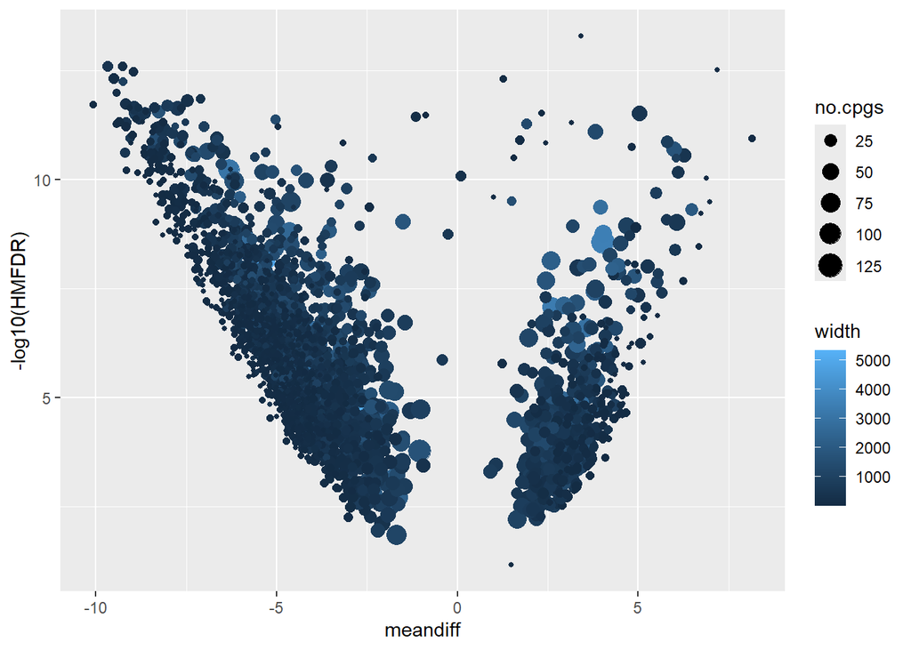

```r
saveRDS(dmrRanges, "dmr.rds")

ggplot(as.data.frame(dmrRanges), aes(meandiff, -log10(HMFDR), colour=width, size=no.cpgs)) + geom_point()
```

```r
dmrRanges <- dmrRanges[order(abs(dmrRanges$meandiff), decreasing=TRUE)]
```

Here we plot a heatmap of the methylation levels of the genes in top 5 differentially methylated regions (DMR) located on chr1.

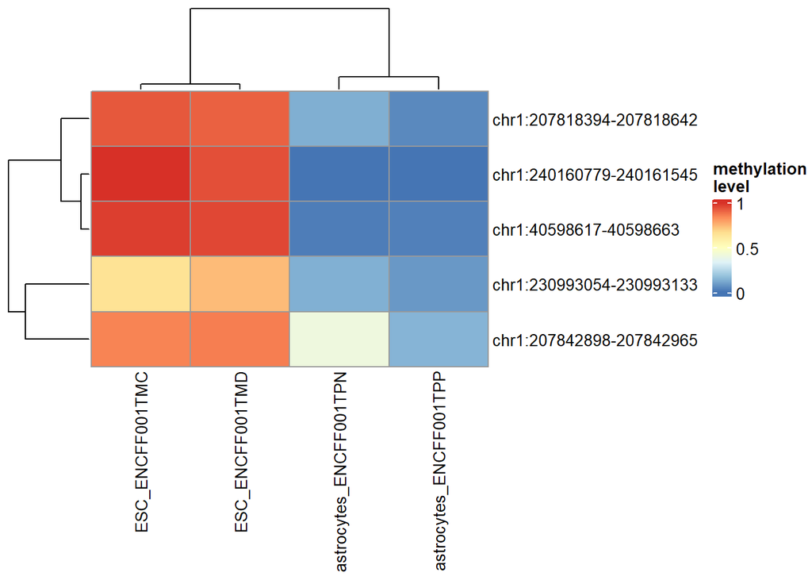

```r
# isolating chr1, selecting the top 5 DMRs
dmr_chr1 <- dmrRanges[seqnames(dmrRanges) %in% c("chr1")]
top_dmr_chr1 <- dmr_chr1[1:5]

# plotting just the top 5 DMRs
met_DMR <- bsseq::getMeth(bs, regions=top_dmr_chr1, what="perRegion")
rownames(met_DMR) <- paste0(as.character(seqnames(top_dmr_chr1)), ":", start(top_dmr_chr1), "-", end(top_dmr_chr1))
pheatmap(met_DMR, name="methylation\nlevel")
```

```r
# getting overlapping genes
gene_names <- top_dmr_chr1$overlapping.genes
gene_names <- gene_names[!is.na(gene_names)]
gene_names <- strsplit(gene_names, ", ")
gene_names <- unique(unlist(gene_names))

# finding the ranges of the genes
hg19_genes <- readRDS("hg19_chr1_genes.rds")
top_genes <- hg19_genes[hg19_genes$symbol %in% gene_names]
# only 2 out of 4 genes of interest were found
```

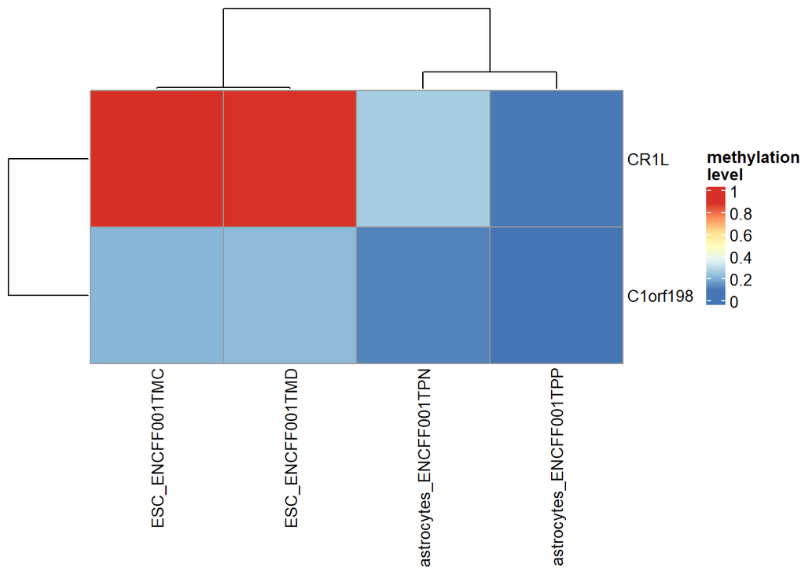

```r
# visualizing methylation of genes in top 5 DMRs
met_genes <- bsseq::getMeth(bs, regions=top_genes, what="perRegion")
rownames(met_genes) <- top_genes$symbol
pheatmap(met_genes, name="methylation\nlevel")
```

# Comparing changes in methylation to accessibility changes

```r
diff_access <- readRDS("diff_accessibility.rds")

# filtering based on significance:
diff_access <- diff_access[diff_access$FDR < 0.05]
diff_access
```

```
## GRanges object with 4143 ranges and 4 metadata columns:
##          seqnames              ranges strand |     logFC    logCPM       PValue
##             <Rle>           <IRanges>  <Rle> | <numeric> <numeric>    <numeric>
##      [1]     chr3   32911212-32911472      * |  -14.5380   2.57720 1.84223e-185
##      [2]     chr8     9007982-9008485      * |  -13.6671   1.65566 6.70803e-143
##      [3]     chr3   57164721-57165102      * |  -15.0043   3.05803 6.19768e-137
##      [4]    chr22   46476146-46476721      * |   14.1114   1.44761 5.26376e-134
##      [5]     chr1   23763045-23763443      * |  -14.5437   2.58018 1.99867e-133
##      ...      ...                 ...    ... .       ...       ...          ...
##   [4139]    chr19       582939-583133      * | -0.537067  -2.50062    0.0245593
##   [4140]    chr20   61716032-61716272      * | -0.658435  -3.09994    0.0250180
##   [4141]    chr16     2390426-2391161      * | -0.390577   3.08249    0.0251418
##   [4142]     chrX 118369934-118370417      * | -0.417196   2.72128    0.0251839
##   [4143]     chrX   18692992-18693328      * |  0.394220   2.12994    0.0254762
##                   FDR
##             <numeric>
##      [1] 1.22824e-180
##      [2] 4.25568e-139
##      [3] 3.09624e-133
##      [4] 2.32832e-130
##      [5] 8.57188e-130
##      ...          ...
##   [4139]    0.0482540
##   [4140]    0.0490440
##   [4141]    0.0492534
##   [4142]    0.0493255
##   [4143]    0.0498228
##   -------
##   seqinfo: 24 sequences from an unspecified genome; no seqlengths
```

```r
dmrRanges <- dmrRanges[dmrRanges$HMFDR < 0.05]
dmrRanges
```

```
## GRanges object with 2579 ranges and 8 metadata columns:
##          seqnames              ranges strand |   no.cpgs min_smoothed_fdr
##             <Rle>           <IRanges>  <Rle> | <integer>        <numeric>
##      [1]     chr9 127029634-127029689      * |         7     5.52823e-119
##      [2]    chr10   97849618-97850058      * |        16     8.29577e-271
##      [3]     chr7 101688615-101688782      * |        15     5.96880e-224
##      [4]    chr20   58662755-58662801      * |         8     1.72388e-115
##      [5]     chr9   33750974-33751117      * |         8     8.04183e-121
##      ...      ...                 ...    ... .       ...              ...
##   [2575]     chr1     1072028-1072838      * |        34      3.60543e-16
##   [2576]     chr2 132233656-132233679      * |         6      2.10622e-20
##   [2577]    chr11   47376578-47377230      * |        19      1.27668e-19
##   [2578]     chr4     8229753-8230302      * |        17      1.23357e-19
##   [2579]     chr1   33235515-33235798      * |        16      1.83495e-15
##              Stouffer       HMFDR       Fisher   maxdiff  meandiff
```

[output cut: 27 more lines]

```r
# adding group labels:
dmrRanges$group = ifelse(dmrRanges$meandiff > 0, "astrocytes_more_methylated", "ESC_more_methylated")
diff_access$group = ifelse(diff_access$logFC > 0, "astrocytes_more_accessible", "ESC_more_accessible")
```

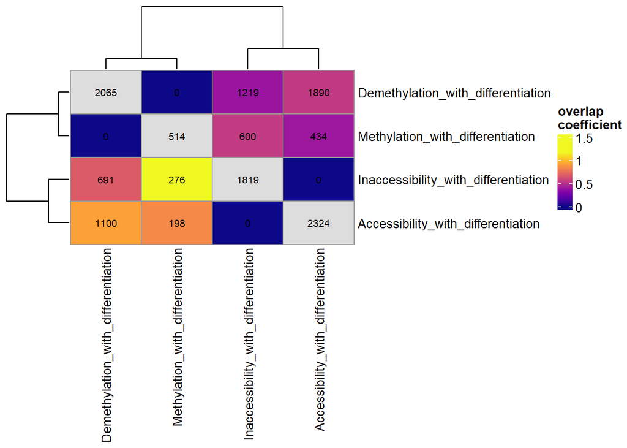

```r
regions <- list(Demethylation_with_differentiation = dmrRanges[dmrRanges$group == "ESC_more_methylated"], Methylation_with_differentiation = dmrRanges[dmrRanges$group == "astrocytes_more_methylated"], Inaccessibility_with_differentiation = diff_access[diff_access$group == "ESC_more_accessible"], Accessibility_with_differentiation = diff_access[diff_access$group == "astrocytes_more_accessible"])

# visualizing overlaps between accessible/methylated regions using a heatmap of overlaps:
regionOverlaps(regions)
```

To assess the extent of agreement between changes in chromatin accessibility and DNA methylation during cell differentiation, I split the DMR and differential accessibility regions based on the direction of change (higher signal in ESCs vs higher signal in differentiated cells). I then visualized the overlaps between these groups using a heatmap. I expected to see an inverse relationship between the two modalities, i.e. regions that are more methylated in one cell type would tend to be less accessible in that same cell type and more accessible in the other. The hypothesis emerges from DNA methylation being linked to gene silencing. The heatmap supports this hypothesis: we observe the highest overlap coefficients between regions that are highly methylated in one cell type and highly accessible in the other. Overall, changes in methylation seem to be inversely related to changes in accessibility during differentiation.